# Ch02 Applied Exercise 10 Notebook

Bruce Hartman

University of St. Francis

2026-08-31 Revised 2026-10-15T08:46:09

Abstract

We analyze the Applied Exercise 10 from Chapter 2 of ISLR (2013), in an R Notebook using modern tidyverse methods.

# Introduction

We will work Ch02 Applied Exercise 10 in this R Notebook. It is found in ISLR (2013) page 56.

# Problem Statement

Here is a statement of the problem, taken from ISLR (2013) page 56.

> 10. This exercise involves the Boston housing data set.
> 1. To begin, load in the Boston data set. The Boston data set is part of the MASS (ed.note now ISLR2) package in R. Now the data set is contained in the object Boston. Read about the data set: How many rows are in this data set? How many columns? What do the rows and columns represent?
> 2. Make some pairwise scatterplots of the drivers (columns) in this dataset. Describe your findings.
> 3. Are any of the drivers associated with per capita crime rate? If so, explain the relationship.
> 4. Do any of the suburbs of Boston appear to have particularly high crime rates? Tax rates? Pupil-teacher ratios? Comment on the range of each driver.
> 5. How many of the suburbs in this data set bound the Charles river?
> 6. What is the median pupil-teacher ratio among the towns in this data set?
> 7. Which suburb of Boston has lowest median value of owner-occupied homes? What are the values of the other predictors for that suburb, and how do those values compare to the overall ranges for those predictors? Comment on your findings.
> 8. In this data set, how many of the suburbs average more than seven rooms per dwelling? More than eight rooms per dwelling? Comment on the suburbs that average more than eight rooms per dwelling.

# Packages

We make all the `mbadtools` required packages available, and also load the `ISLR2` package for data.

```r
library(ISLR2) # some data files
# install mbadtools from github
if(!("mbadtools" %in% installed.packages())) pak::pak("bhartman2/mbadtools")
# load github packages
library(mbadtools)
```

# Data (a)

The Boston data set is in the `ISLR2` package.

```r
data(Boston)
Boston
```

|  | crim | zn | indus | chas | nox | rm | age | dis | rad | tax | ptratio | black | lstat | medv |
| --- | --- | --- | --- | --- | --- | --- | --- | --- | --- | --- | --- | --- | --- | --- |
| 1 | 0.00632 | 18.0 | 2.31 | 0 | 0.5380 | 6.575 | 65.2 | 4.0900 | 1 | 296 | 15.3 | 396.90 | 4.98 | 24.0 |
| 2 | 0.02731 | 0.0 | 7.07 | 0 | 0.4690 | 6.421 | 78.9 | 4.9671 | 2 | 242 | 17.8 | 396.90 | 9.14 | 21.6 |
| 3 | 0.02729 | 0.0 | 7.07 | 0 | 0.4690 | 7.185 | 61.1 | 4.9671 | 2 | 242 | 17.8 | 392.83 | 4.03 | 34.7 |
| 4 | 0.03237 | 0.0 | 2.18 | 0 | 0.4580 | 6.998 | 45.8 | 6.0622 | 3 | 222 | 18.7 | 394.63 | 2.94 | 33.4 |
| 5 | 0.06905 | 0.0 | 2.18 | 0 | 0.4580 | 7.147 | 54.2 | 6.0622 | 3 | 222 | 18.7 | 396.90 | 5.33 | 36.2 |
| 6 | 0.02985 | 0.0 | 2.18 | 0 | 0.4580 | 6.430 | 58.7 | 6.0622 | 3 | 222 | 18.7 | 394.12 | 5.21 | 28.7 |
| 7 | 0.08829 | 12.5 | 7.87 | 0 | 0.5240 | 6.012 | 66.6 | 5.5605 | 5 | 311 | 15.2 | 395.60 | 12.43 | 22.9 |
| 8 | 0.14455 | 12.5 | 7.87 | 0 | 0.5240 | 6.172 | 96.1 | 5.9505 | 5 | 311 | 15.2 | 396.90 | 19.15 | 27.1 |
| 9 | 0.21124 | 12.5 | 7.87 | 0 | 0.5240 | 5.631 | 100.0 | 6.0821 | 5 | 311 | 15.2 | 386.63 | 29.93 | 16.5 |
| 10 | 0.17004 | 12.5 | 7.87 | 0 | 0.5240 | 6.004 | 85.9 | 6.5921 | 5 | 311 | 15.2 | 386.71 | 17.10 | 18.9 |

[output cut: 496 more lines]

There are 14 columns and 506 rows. What do the columns and rows represent? Show the help page for the Boston data set in the Help tab if you are running the notebook interactively.

```r
help("Boston", package="ISLR2")
```

# Data Description

What do the data look like?

```r
Boston %>% skim
```

```
── Data Summary ────────────────────────
                           Values
Name                       Piped data
Number of rows             506
Number of columns          14
_______________________
Column type frequency:
  numeric                  14
________________________
Group variables            None
```

|  | skim_variable | n_missing | complete_rate | mean | sd | p0 | p25 | p50 | p75 | p100 | hist |
| --- | --- | --- | --- | --- | --- | --- | --- | --- | --- | --- | --- |
| 1 | crim | 0 | 1 | 3.61352356 | 8.6015451 | 0.00632 | 0.082045 | 0.25651 | 3.677083 | 88.9762 | ▇▁▁▁▁ |
| 2 | zn | 0 | 1 | 11.36363636 | 23.3224530 | 0.00000 | 0.000000 | 0.00000 | 12.500000 | 100.0000 | ▇▁▁▁▁ |
| 3 | indus | 0 | 1 | 11.13677866 | 6.8603529 | 0.46000 | 5.190000 | 9.69000 | 18.100000 | 27.7400 | ▇▆▁▇▁ |
| 4 | chas | 0 | 1 | 0.06916996 | 0.2539940 | 0.00000 | 0.000000 | 0.00000 | 0.000000 | 1.0000 | ▇▁▁▁▁ |
| 5 | nox | 0 | 1 | 0.55469506 | 0.1158777 | 0.38500 | 0.449000 | 0.53800 | 0.624000 | 0.8710 | ▇▇▆▅▁ |
| 6 | rm | 0 | 1 | 6.28463439 | 0.7026171 | 3.56100 | 5.885500 | 6.20850 | 6.623500 | 8.7800 | ▁▂▇▂▁ |
| 7 | age | 0 | 1 | 68.57490119 | 28.1488614 | 2.90000 | 45.025000 | 77.50000 | 94.075000 | 100.0000 | ▂▂▂▃▇ |
| 8 | dis | 0 | 1 | 3.79504269 | 2.1057101 | 1.12960 | 2.100175 | 3.20745 | 5.188425 | 12.1265 | ▇▅▂▁▁ |
| 9 | rad | 0 | 1 | 9.54940711 | 8.7072594 | 1.00000 | 4.000000 | 5.00000 | 24.000000 | 24.0000 | ▇▂▁▁▃ |
| 10 | tax | 0 | 1 | 408.23715415 | 168.5371161 | 187.00000 | 279.000000 | 330.00000 | 666.000000 | 711.0000 | ▇▇▃▁▇ |

[output cut: 4 more lines]

There are no missing rows, and all data are numeric except that `chas` is probably a 0-1 variable. To check that we can do this:

```r
Boston %>% distinct(chas)
```

| chas |
| --- |
| 0 |
| 1 |

Yes, there are only two values: on the Charles River or not.

# Part (b)

Make some pairwise scatterplots of the predictors (columns) in this data set. Describe your findings. We will use a pairs plot. There are lots of variables so it’s complex.

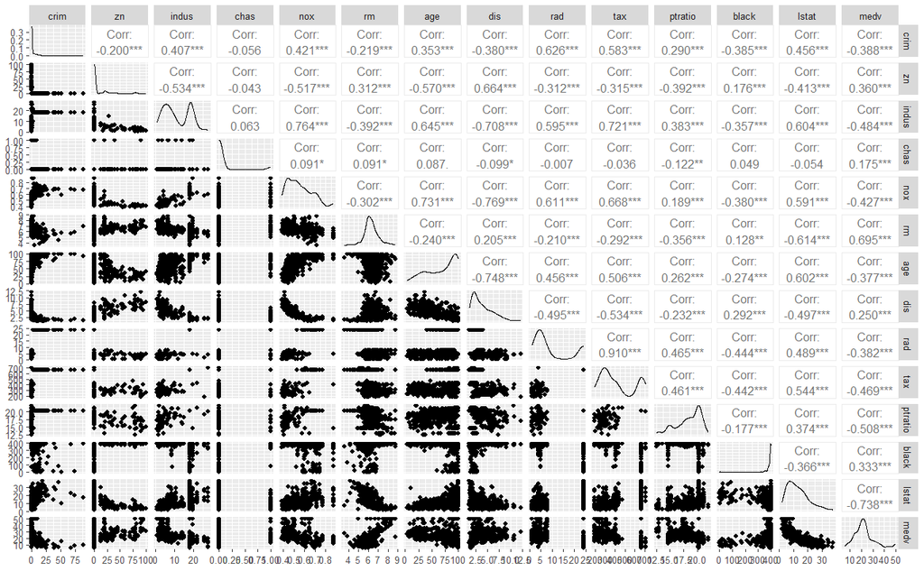

```r
Boston %>% ggpairs(progress=F)
```

Certain columns do not show signs of lots of correlation. Pick them out by eye.

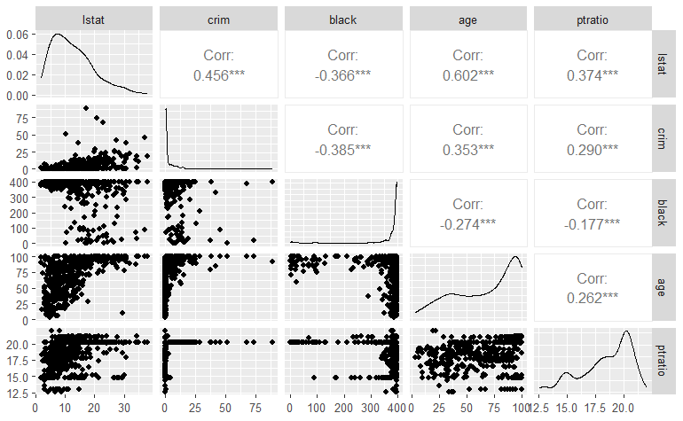

```r
several=Boston[,c(13,1,12,7,11)]
ggpairs(several, progress=F)
```

```r
several %>% cor() %>% round(digits=2)
```

```
        lstat  crim black   age ptratio
lstat    1.00  0.46 -0.37  0.60    0.37
crim     0.46  1.00 -0.39  0.35    0.29
black   -0.37 -0.39  1.00 -0.27   -0.18
age      0.60  0.35 -0.27  1.00    0.26
ptratio  0.37  0.29 -0.18  0.26    1.00
```

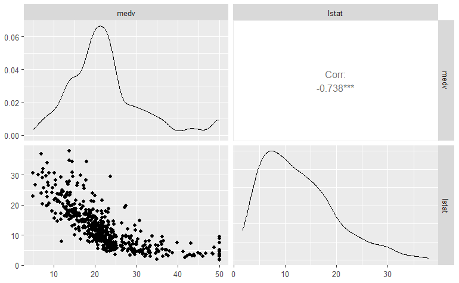

```r
two=Boston %>% select(medv, lstat)
ggpairs(two, progress=F)
```

`medv` seems to be negatively related to `lstat`. These are the median value of owner-occupied homes in each suburb, and the lower status of the population in percent. The correlation is -.738 and the graph shows the trend clearly. It looks kind of like a curved descent.

# Research Hypothesis

- Hypothesis: As `lstat` increases, `medv` decreases, on average.

This hypothesis makes sense from a business perspective, since `medv` is the median home value in a town, and `lstat` is the percent of the population that is of lower status.

# Part (c)

Are any of the predictors associated with per capita crime rate? If so, explain the relationship. Column 1 is `crim`, the crime rate. We can easily look at the correlations with the first column.

```r
Boston %>% cor %>% as.data.frame %>%
  select(crim) %>%
  transmute(Correlation=crim)
```

|  | Correlation |
| --- | --- |
| crim | 1.00000000 |
| zn | -0.20046922 |
| indus | 0.40658341 |
| chas | -0.05589158 |
| nox | 0.42097171 |
| rm | -0.21924670 |
| age | 0.35273425 |
| dis | -0.37967009 |
| rad | 0.62550515 |
| tax | 0.58276431 |

[output cut: 4 more lines]

`crim` does not seem to be very related to any one variable, though the correlation is highest positive with `rad, tax,lstat, nox` and negative with `medv`.

# Part (d)

Do any of the suburbs of Boston appear to have particularly high crime rates? Tax rates? Pupil-teacher ratios? Comment on the range of each predictor.

We will define >=mean to be excessive crime.

```r
Boston %>% skim %>% select(skim_variable, numeric.mean) %>%
  as_tibble %>% rename(Mean=numeric.mean)
```

| skim_variable | Mean |
| --- | --- |
| crim | 3.61352356 |
| zn | 11.36363636 |
| indus | 11.13677866 |
| chas | 0.06916996 |
| nox | 0.55469506 |
| rm | 6.28463439 |
| age | 68.57490119 |
| dis | 3.79504269 |
| rad | 9.54940711 |
| tax | 408.23715415 |

[output cut: 4 more lines]

The mean of `crim` is about 3.61. Count how many rows have `crim`above this number.

```r
# tidyverse way
Boston %>% filter(crim >= mean(crim)) %>% count
```

| n |
| --- |
| 128 |

128 communities have `crim` above the mean. That is out of 506 communities.

Let’s look at all of the relevant columns.

```r
Boston %>% filter(crim>=mean(crim) ) %>% count
```

| n |
| --- |
| 128 |

```r
Boston %>% filter(tax>=mean(tax) ) %>% count
```

| n |
| --- |
| 168 |

```r
Boston %>% filter(ptratio>=mean(ptratio) ) %>% count
```

| n |
| --- |
| 292 |

There are 128, 168, and 292 above the means of `crim, tax, ptratio` respectively. Most by far have low `crim` rates.

We can also see this using histograms. Start with `crim`. The mean will be shown as a blue vertical dashed line. We will use bars that have red fill and a black outline (‘color’ parameter), and we will fade the red color a bit (parameter ‘alpha’), for readability. Picking the number of bins is an analyst decision.

[figure not shown]

```r
gpcr = ggplot(Boston) +
  geom_histogram(aes(crim), fill="red", color="black", alpha=0.5, bins=20) +
  geom_vline(aes(xintercept=mean(crim)), linetype="dashed", color="blue")
gpcr
```

Most suburbs have crime rates below the mean, bout one has a rate up around 90.

[figure not shown]

```r
gptx = ggplot(Boston) +
  geom_histogram(aes(tax), fill="red", color="black", alpha=0.5, bins=20)+
  geom_vline(aes(xintercept=mean(tax)), linetype="dashed", color="blue")
gptx
```

Taxes are mostly below the mean, but there are two big ones.

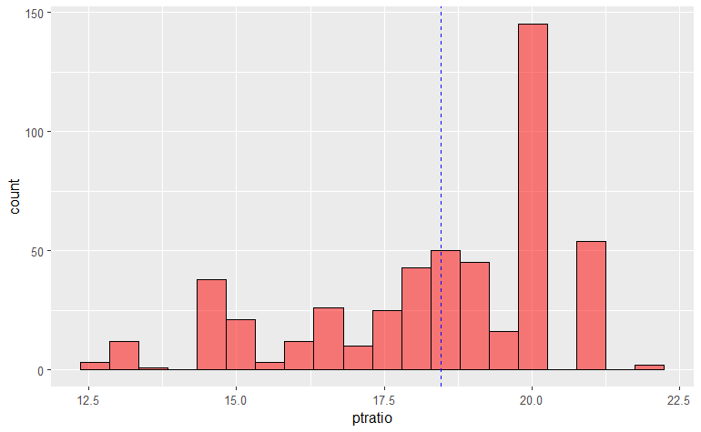

```r
gpptr = ggplot(Boston) +
  geom_histogram(aes(ptratio), fill="red", color="black", alpha=0.5, bins=20)+
  geom_vline(aes(xintercept=mean(ptratio)), linetype="dashed", color="blue")
gpptr
```

For `ptratio`, most communities are above the mean, not as desirable, but some are as low as 12 or 13. Those pupil-teacher ratios are very good.

All plots together:

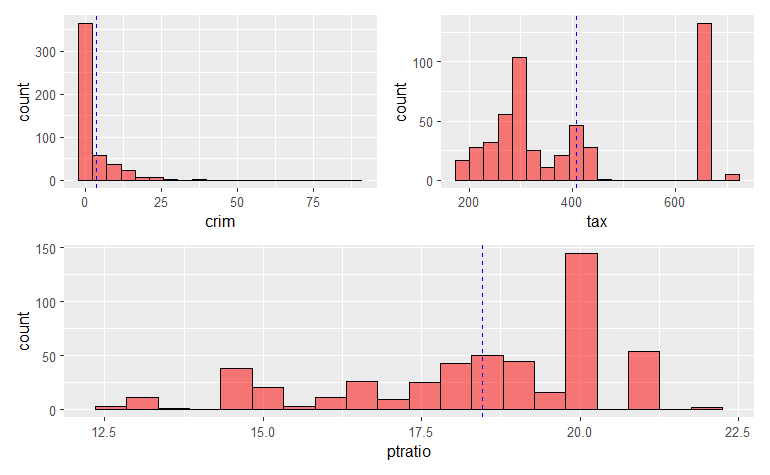

```r
(gpcr | gptx) / gpptr
```

# Part (e)

How many of the suburbs in this data set bound the Charles river?

```r
Boston %>% group_by(chas) %>% summarize("Charles" = n())
```

| chas | Charles |
| --- | --- |
| 0 | 471 |
| 1 | 35 |

There are 35 of them.

# Part (f)

What is the median pupil-teacher ratio among the towns in this data set? I will use the `quantile` function here and set the quantile I want to .50, which is the median. By changing the number, I could get any quantile I want. The .50 quantile is the median, in statistics.

```r
Boston %>% summarize( "Median ptratio" = quantile(ptratio, .50) )
```

| Median ptratio |
| --- |
| 19.05 |

The median is given above. which suburbs have `ptratio` above the mean?

```r
Boston %>% mutate(r = row_number(), .before=1) %>%
  select(r, ptratio) %>%
  filter(ptratio > mean(ptratio)) %>%
  arrange(desc(ptratio))
```

| r | ptratio |
| --- | --- |
| 355 | 22.0 |
| 356 | 22.0 |
| 128 | 21.2 |
| 129 | 21.2 |
| 130 | 21.2 |
| 131 | 21.2 |
| 132 | 21.2 |
| 133 | 21.2 |
| 134 | 21.2 |
| 135 | 21.2 |

[output cut: 282 more lines]

```r
Boston %>% mutate(r = row_number(), .before=1) %>%
    select(r, ptratio) %>%
    filter (between(ptratio, median(ptratio)-.05, median(ptratio)+.045) )
```

| r | ptratio |
| --- | --- |
| 81 | 19 |
| 82 | 19 |
| 83 | 19 |
| 84 | 19 |

Rows 81 through 84 have `ptratio` near the median, defined as within .05 below and .045 above the median.

# Part (g)

Which suburb of Boston has lowest median value of owner-occupied homes (`medv`)? What are the values of the other predictors for that suburb, and how do those values compare to the overall ranges for those predictors? Comment on your findings.

```r
Boston %>% mutate (r = row_number(), .before=1) %>%
  filter( medv == min(medv) )
```

| r | crim | zn | indus | chas | nox | rm | age | dis | rad | tax | ptratio | black | lstat | medv |
| --- | --- | --- | --- | --- | --- | --- | --- | --- | --- | --- | --- | --- | --- | --- |
| 399 | 38.3518 | 0 | 18.1 | 0 | 0.693 | 5.453 | 100 | 1.4896 | 24 | 666 | 20.2 | 396.90 | 30.59 | 5 |
| 406 | 67.9208 | 0 | 18.1 | 0 | 0.693 | 5.683 | 100 | 1.4254 | 24 | 666 | 20.2 | 384.97 | 22.98 | 5 |